# Etude de la valeur marchande des joueurs de football des cinq principaux championnats européens

Auteurs : Timothée Son–Gauthier, Steve Éleonore, Farid Belhiteche

L3 MIASHS - Université de Paris

2020/2021

## Introduction

Ces transferts ont toujours existé dans le football, et donnent lieu à des surenchères telles, que certains transferts historiques ont atteint des sommes très élevées, allant jusqu’à 222 millions d’euros (Neymar signant pour le club Paris-Saint-Germain, en 2019). Cependant, nous sommes forcés de constater que tous les joueurs ne valent pas autant sur le marché.

Ainsi, nous nous proposons d’étudier le lien entre la valeur marchande d’un joueur et certaines de leurs caractéristiques que nous avons pu recueillir.

## Table des matières

1. Présentation des variables utilisées et formulation d’hypothèses
2. Corrélations entre les différentes caractéristiques des joueurs et leur valeur marchande
3. Aperçus sur la valeur marchande des joueurs
4. L’implication du joueur dans les buts : le facteur explicatif à privilégier ?
5. Analyse bivariée valeur marchande - implication dans les buts
6. UC Fit : Ajustement
7. UC Predict : Prédiction

## Présentation des variables utilisées et formulation d’hypothèses

Nous avons pu trouver les données nécessaires sur le site dédié [transfermarkt.fr](https://www.transfermarkt.fr/), une plateforme influente dans le monde du football, constituant la plus grosse base de donnée en accès libre du milieu à ce jour.

Ainsi, nous avons pu récolter $N=430$ observations, correspondant à chaque avant-centre participant aux championnats considérés, c’est-à-dire les cinq principaux championnats européens.

Nous avons donc retenu 7 caractéristiques afin de tenter d’expliquer nos valeurs marchandes. Toutes sont a priori quantitatives.

#### $Y$ : La valeur marchande du joueur

Cette variable correspond à la valeur marchande du joueur à la fin de l’année 2020, en millions d’euros. Cette valeur suit le joueur tout au long de sa carrière, et est assez fluctuante au cours temps. En effet, nous pouvons prendre l’exemple du joueur Mbappe : sa valeur marchande à la fin de l’année 2020 était de 180 milllions d’euros, alors qu’elle était de 200 millions d’euros en décembre 2018, juste après la coupe du monde. Nous nous réservons l’étude plus en détail de cette variable pour la suite de notre projet.

#### $X_1$ : Implication du joueur dans les buts

Cette variable comptabilise le nombre de buts dans lesquels le joueur est impliqué, regroupant buts marqués ainsi que passes décisives. Nous reviendrons également en détail sur cette variable dans la suite de notre étude. Nous pouvons formuler l’hypothèse que la valeur marchande d’un joueur augmente selon le nombre de buts et passes décisives dans lequel il est impliqué.

#### $X_2$ : Contribution du joueur dans les buts de l’équipe

Cette variable n’est autre que $X_1$ normalisée par le nombre total de buts de l’équipe. On prévoit de même une augmentation de la valeur marchande selon la valeur de $X_2$ .

#### $X_3$ : Âge du joueur

Cette variable est exprimée en années. L’âge étant dans la plupart des cas synonyme de régression des capacités physiques et sportives, nous formulons l’hypothèse que la valeur marchande d’un joueur diminue en fonction de son âge.

#### $X_4$ : Durée de contrat restante dans l’équipe actuelle

Cette durée est également exprimée en années. C’est sûrement la variable pour laquelle il est le plus difficile d’émettre une hypothèse. En effet, un joueur fortement convoité peut voir sa valeur pérécliter au cours de son contrat, tandis qu’un autre peut se révéler en fin de contrat et gagner en valeur.

#### $X_5$ : Classement du club

Cette variable nous informe sur le classement du club du joueur considéré par rapport au championnat dans lequel il concourt. Notre hypothèse est que la valeur marchande d’un joueur dont l’équipe est bien classée est en général supérieure à celle d’autres joueurs de clubs moins bien classés. Ainsi, $Y$ diminuerait lorsque $X_5$ augmenterait.

#### $X_6$ : Nombre de sélections internationales

Cette variable comptabilise le nombre de matchs joués par le joueur à l’international. Nous estimons que les joueurs représentant leur pays sont censés être les meilleurs, tant les enjeux d’un match à l’international sont grands. Ainsi, $Y$ augmenterait avec $X_6$.

#### $X_7$ : Popularité

L’indicateur que nous avons choisi d’utiliser afin de mesurer la popularité du joueur est son nombre d’abonnés sur les réseaux sociaux (Instagram / Twitter le cas échéant). Nous formulons finalement l’hypothèse que la valeur marchande d’un joueur et sa popularité sont corrélées positivement.

## Corrélations entre les différentes caractéristiques des joueurs et leur valeur marchande

Afin d’étudier la relation existante entre nos variables de façon effective, nous pouvons dresser la matrice de corrélation associée à notre jeu de données, et voir que, finalement, nos hypothèses sur les variables sont validées.

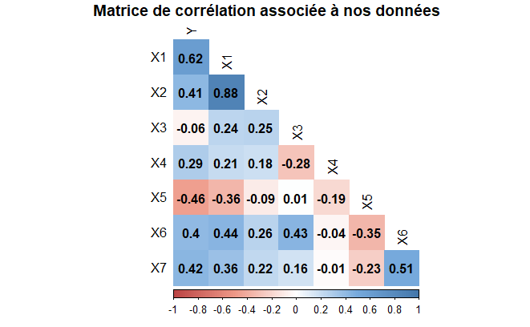

Au-delà de ça, il y a plusieurs points intéressants.

En effet, nous pouvons tout d’abord remarquer que la variable qui semble être en plus forte corrélation avec $Y$ est $X_1$, qui représente l’implication du joueur dans les buts, avec un coefficient de corrélation égal à 0.62. les coefficients reliant les autres variables à $Y$ étant bien en deçà de cette valeur, nous ferons, par la suite, de $X_1$ une caractéristique privilégiée afin d’expliquer la variable $Y$.

Ensuite, nous pouvons voir que l’âge (représenté par $X_3$) est la variable la plus faiblement corrélée (en valeur absolue), mais aussi que celle-ci est corrélée négativement à $Y$, ce qui laisse sous-entendre que l’âge est une facteur de diminution de la valeur d’un joueur, mais pas autant que l’on pourrait le penser (ici, l’âge est inclus dans l’intervalle [16;40]) .

Enfin, nous pouvons voir que d’après nos données, le coefficient de corrélation entre $X_4$ (la durée de contrat restante dans le club actuel) et la valeur marchande du joueur est positif (égal à 0.29). Ainsi, la tendance mise en lumière serait une augmentation de la valeur marchande en fonction de la durée de contrat restante.

## Aperçus sur la valeur marchande des joueurs

Nous nous proposons maintenant d’étudier exclusivement la répartition de la variable Y.

Affichons d’emblée les statistiques sommaires de la valeur marchande (en millions d’euros) :

| Min | 1er quartile | Médiane | Moyenne | 3ème quartile | Max | Ecart-type |
| --- | --- | --- | --- | --- | --- | --- |
| 0.075 | 2.4 | 6.5 | 15.254 | 17.250 | 180 | 22.957 |

Nous pouvons voir que l’écart-type est bien supérieur à la moyenne de nos valeurs, ce qui dénote l’assez grande disparité que nous pouvons retrouver dans nos valeurs. En effet, il y a un joueurs atteignant les 180 millions d’euros de valeur marchande tandis que la médiane est fixée à 6.5 millions d’euros.

Analysons maintenant la répartition des valeurs de $Y$ en traçant la fonction de répartition empirique de la valeur marchande.

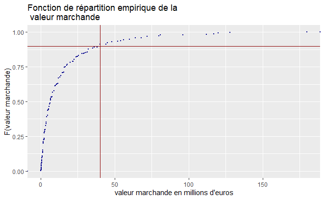

En analysant la répartition de ces valeurs, nous pouvons voir que 90% des valeurs sont en-dessous de 40 millions d’euros.

Afin d’étudier la relation entre $X_1$ (le nombre de buts et de passes décisives dans lesquelles est impliqué le joueur) et $Y$, nous souhaitons réaliser une analyse bivariée (quantitative-quantitative). Ainsi, notre but est de discrétiser (c’est-à-dire séparer en différentes classes) nos deux variables ; à commencer par $Y$.

La disparité des valeurs nous pose problème. En effet, compte tenu de la richesse des profils correspondant aux valeurs marchandes présentes dans l’intervalle ]40;180], il nous est impossible de faire l’impasse sur ces valeurs, bien que la répartition de ces valeurs reste tout de même disparate dans cet intervalle. C’est pourquoi nous faisons le choix d’isoler ces valeurs en une classe, qui contiendra les “Très hautes valeurs”, c’est-à-dire les 10% de valeurs marchandes les plus élevées.

Afin de décider du découpage en classes des valeurs restantes, nous utiliserons la méthode de Scott, afin d’obtenir des intervalles de longueur égale, exploitant les informations que l’on a sur les données, en l’occurence l’écart-type :

$$K=\frac{(Max-Min)\sqrt[3](N)}{3.5 \sigma}$$

avec $\sigma$ l’écart-type, et $N$ le nombre de valeurs de Y, et $K$ le nombre d’intervalles de taille égale pour un découpage optimal.

En appliquant cet indice à la totalité de nos données, nous obtenions $K_1 = 17$, ce qui état un nombre d’intervalles unn peu trop élevé à notre goût. Ainsi, en isolant les 90% de valeurs marchandes les moins élevées ($Y'$), on obtient un écart-type $\sigma_2=9.863$, et donc on a $K_2 = 8.48$ pour l’indice de Scott. Ainsi, nous séparons $Y$ en $8+1=9$ classes afibn d’avoir un découpage “optimal”.

On devrait alors séparer $Y'$ = $Y$[$\le$ 40] en 8 classes, ce qui nous ferait des inntervalles de longueur 5 millions. Or, compte-tenu des petites concentrations de valeurs dans les catégories 25-30, 30-35 et 35-40, on se propose de fusionner les 3 classes, ainsi que les deux classes 15-20 et 20-25, afin d’avoir une distribution homogène tenant compte des divers paliers, et donc nous nous retrouvons avec 6 classes :

[output not shown]

Ainsi, nous pouvons représenter graphiquement la part des différentes classes de valeurs marchandes dans nos données :

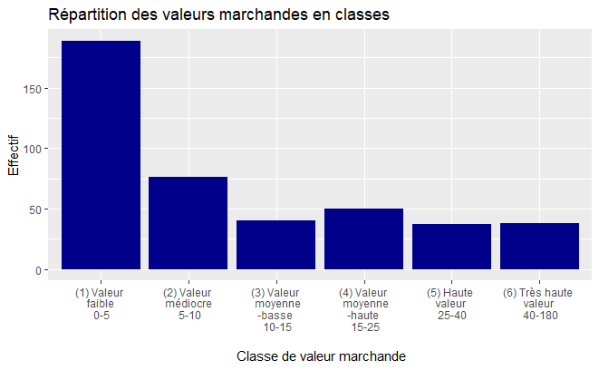

## L’implication du joueur dans les buts : le facteur explicatif à privilégier ?

Étant donné que l’indice de corrélation entre l’implication dans les buts et la valeur marchande du joueur dépasse de loin les autres (0,62), tout en étant plus proche de 1 que de 0, on va considérer $X_1$ comme la variable explicative principale de $Y$.

Avant de réaliser notre analyse bivariée, nous allons étudier la distribution de la variable $X_1$. Comme pour l’étude de $Y$, nous allons commencer par un résumé de ses statistiques principales :

| Min | 1er quartile | Médiane | Moyenne | 3ème quartile | Max | Ecart-type |
| --- | --- | --- | --- | --- | --- | --- |
| 0 | 1 | 6 | 8.023 | 12 | 47 | 8.143 |

Nous pouvons voir que cette distribution est assez identique à la précédente, dans le sens où le maximum de $X_1$ est nettement supérieur à sa médiane. Cependant, dans ce cas de figure, l’écart-type et la moyenne sont très proches. On en conclut dont que ces valeurs sont un peu moins disparates que les précédentes, ce qui peut se lire sur la fonction de répartition dont la pente est un peu plus adoucie que pour $Y$ :

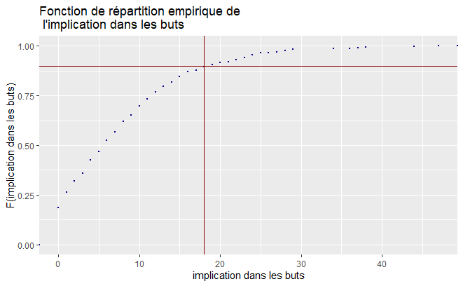

Comme précédemment, en analysant la répartition des valeurs, nous pouvons voir que 90% des des données sont en-dessous de 18 buts. Nous pouvons nous servir de cette information afin de discrétiser $X_1$ comme nous l’avons fait plus tôt avec $Y$ :

On peut alors découper $X_1$ en 6 classes en utilisant la méthode de Scott pour nous guider :

[output not shown]

Ainsi, nous pouvons maintenant représenter la répartition des valeurs de $X_1$ suivant ces classes :

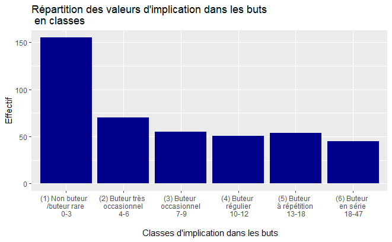

Nous pouvons ainsi voir que la répartition des valeurs de $Y$ et $X_1$ suivant différentes classes est assez similaire, dans le sens où il y a une classe (celle avec les valeurs les plus faibles) qui est majoritaire, contenant environ 3 fois plus de valeurs que les autres classes, qui se répartissent alors les valeurs restantes de façon assez homogène.

## Analyse bivariée “valeur marchande - implication dans les buts”

Afin de mesurer la répartition de nos données à l’intérieur des classes respectives de valeur marchande et d’implication dans les buts, nous allons dresser la table d’attraction-répulsion des modalités du couple $(X_1,Y)$. Si la table de contingence constitue un outil puissant afin d’étudier les relations entre les différentes classes de $X_1$ et $Y$, le fait d’étudier les indices d’attraction/répulsion de ces modalités nous offre un degré d’interprétation supplémentaire.

|  | $Y=$**“valeur faible”** | $Y=$**“valeur médiocre”** | $Y=$**“valeur moyenne-basse”** | $Y=$**“valeur moyenne-haute”** | $Y=$**“haute valeur”** | $Y=$**“très haute valeur”** |
| --- | --- | --- | --- | --- | --- | --- |
| $X_1=$ **“non buteur / buteur rare”** | 1.72 | 0.77 | 0.42 | 0.39 | 0.07 | 0.22 |
| $X_1=$**“buteur très occasionnel”** | 1.01 | 1.45 | 1.07 | 1.23 | 0.50 | 0.16 |
| $X_1=$**“buteur occasionnel”** | 0.83 | 1.23 | 1.17 | 1.25 | 1.06 | 0.82 |
| $X_1=$**“buteur régulier”** | 0.58 | 1.33 | 1.90 | 1.69 | 1.37 | 0.22 |
| $X_1=$**“buteur à répétition”** | 0.34 | 1.15 | 1.59 | 1.43 | 2.58 | 1.26 |
| $X_1=$**“buteur en série”** | 0.00 | 0.25 | 0.95 | 1.15 | 2.58 | 5.78 |

Ainsi, nous pous relever plusieurs valeurs remarquables.

Tout d’abord, le coefficient d’attraction du couple (“buteur en série”,“très haute valeur”) qui est de 5.78 : c’est la valeur la plus haute, idiquant donc la plus forte attraction toutes classes confondues. Nous le rappelons, ces deux classes constituent les 10% supérieurs de nos données, que ce soit pour $X_1$ ou $Y$.

Ensuite, nous avons une valeur de 0 pour le couple(“buteur en série”,“valeur faible”), ce qui s’explique par le fait que la contingence entre ces deux classes est de 0. Il y a donc une répulsion totale entre ces deux classes.

Au contraire, la classe “buteur occasionnel”, qui correspond à une implication entre 7 et 9 buts (on rappelle que la moyenne de $X_1$ est fixée à 8.023) est celle qui possède les indices d’attraction-répulsion les plus proches de 1, ce qui dénote une répartition assez homogènne de ces profils de joueurs dans les différentes classes de valeur marchande.

## Conclusion de première partie :

Ainsi, nous pouvons voir que le lien existant entre nos deux variable $X_1$ et $Y$ est plus fort pour les valeurs dites “extrêmes” que pour les valeurs “intermédiaires” de notre jeu de données. En effet, d’après la table de contingence, aucun joueur n’ayant été impliqué dans plus de 18 buts n’a de valeur marchande inférieure à 5 millions d’euros, et réciproquement, seulement 3 joueurs (sur 430) ayant été impliqués dans moins de 3 buts possèdent une valeur marchande superieure à 40 millions d’euros.

Cependant, on estime les résultats peu concluants sur les données dites “intermédiaires”, que ce soit en terme de valeur marchande ou bien d’implication dans les buts. En effet, les profils de buteurs moyens nous montrent que peut-être, d’autres facteurs sont responsables de l’homogénéité de leur répartition dans les différentes classes de valeur marchande, ce qui est corroboré par la matrice de corrélation.

De plus, la discrétisation de données apparemment continues implique inéluctablement une “erreur de discrétisation”. Les classes construites ne sont peut-être pas optimales afin de traîter cette problématique.

Ainsi, nous nous proposons pour la suite de notre étude de reconsidérer $Y$ comme une variable quantitative, mais également d’étudier son lien avec le reste de nos variables afin de voir si nous pouvons l’expliquer encore plus précisément.

## UC Fit : ajustement

Dans cette partie, nous allons chercher le meilleur ajustement de $Y$ en fonction de nos régresseurs. Dans un souci de clarté, nous ne noterons plus les variables $X_i$, mais $X^i$ $\forall i \in [1;7]$

#### 1) Régression linéaire simple : Y ~X1

Les résultats de la partie précédente, c’est-à-dire l’analyse bivariée de $X^1$ et $Y$ en tant que variables qualitatives n’étant pas concluants, nous choisissons maintenant de revenir dans le cas de figure où elles sont quantitatives.

L’étude de la matrice de corrélations nous a précédemment renseigné sur le fait qu’il existe une corrélation positive entre la valeur marchande $Y$ et le nombre de buts $X^1$ (de 0.62). Ainsi, nous nous proposons de voir s’il est possible de représenter cette relation via un modèle de régression simple.

On obtient alors la courbe de régression linéaire suivante :

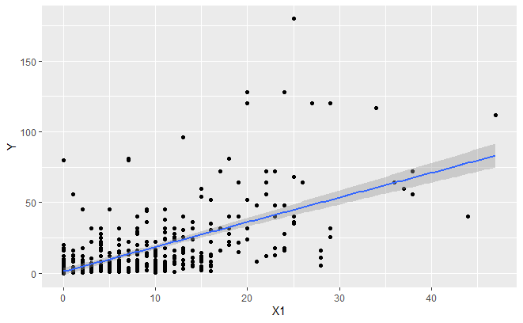

L’équation de la droite de régression est $y = 1.7416x+1.2805$,

Ce qui correespond à l’estimation de $Y$ suivante :

$\forall i\in [1;430], \hat{Y}_i=1.7416 \times X^1_i+1.2805\times1$

Et donc, finalement, on a : $\forall i\in [1;430], Y_i = \hat{Y}_i+ \hat{u}_i=1.7416 \times X^1_i+1.2805\times1 + \hat{u}_i$

Avec $\hat{u}$ le vecteur des résidus, quantifiant l’écart entre la modélisation et les données réelles, et 1 un coefficient de l’intercept .

Voici des indicateurs sur cette régression linéaire simple :

| a | b | écart-type standard des résidus | erreur sur a | erreur sur b | Fisher | Student sur $X^1$ | Student sur $1$ | R² | R² ajusté |
| --- | --- | --- | --- | --- | --- | --- | --- | --- | --- |
| 1.7416 | 1.2805 | 18.07 | 0.1071 | 1.2241 | F = 264.2, et p-value < $2.2e^-16$ | $t=16.255$ et p-value < $2.2e^-16$ | $t=1.046$ et p-value $= 0.296$ | 0.3817 | 0.3803 |

*Rappel :*

*Test de Fisher global :*

- $H_0$ *: la régression est globalement non significative*
- $H_1$ *: la régression est globalement significative*

*Test de Student :*

- $H_0$ *: La variable considérée est non significative dans cette modélisation*
- $H_1$ *: La variable considérée est significative*

*Pour ces deux tests, on prendra un seuil* $\alpha = 0.05$ *pour les p-values: si la p-value du test est inférieure à 0.05, on rejette* $H_0$*.*

Bilan :

Nous pouvons remarquer plusieurs choses :

- Le test de Fisher nous indique que la régression est significative : la p-value est proche de 0
- Le test de Student pour $X^1$ nous indique également que cette variable est significative.
- Cependant, ce n’est pas le cas pour l’intercept, qui ne passe pas le test de Student avec une p-value de presque 30%, et dont l’erreur sur le coefficient n’est pas négligeable (l’erreur est quasiment équivalente à la valeur).
- Le R² est égal à 0.3817, ce qui signifie que le modèle explique environ 38% de nos données, ce qui n’est pas très élevé.

On ne peut cependant pas retirer l’intercept de notre modélisation, car cela biaiserait nos résultats.

*Rappel :* *Comme précédemment, on se fixe une valeur seuil* $\alpha=0.05$ *pour les p-values des tests suivants.*

*Test de Durbin-Watson :*

- $H_0$ *: Les résidus sont auto-corrélés*
- $H_1$ *: Les résidus sont indépendants*

*Test de Shapiro :*

- $H_0$ *: Les résidus ne suivent pas une loi normale*
- $H_1$ *: Les résidus suivent une loi normale*

*Test de Breush-Pagan :*

- $H_0$ *: La variance des résidus n’est pas constante*
- $H_1$ *: La variance des résidus est constante*

| **Caractéristique** | Non-corrélation | Normalité | Homoscédasticité | Centrage |
| --- | --- | --- | --- | --- |
| **Test** | Durbin-Watson (autocorrélation des résidus) | Shapiro (non normalité) | Breush-Pagan (non constance de la variance) | Moyenne (estimation de l’espérance pour n grand) |
| **Résultat du test** | Non corrélation des résidus : p-value < $2.2e^-16$ | Normalité des résidus : p-value <$2.2e^-16$ | Constance de la variance des résidus : p-value < $2.2e^-16$ | Les résidus sont centrés $\overline{\hat{u}}=1.e^-14$ |

Regardons maintenant s’il y a des valeurs “abérrantes”, en nous appuyant sur la distance de Cook pour discerner d’éventuels effets de levier :

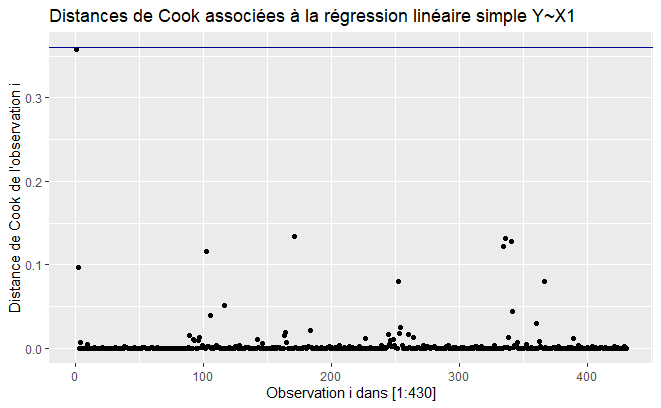

En analysant les distances de cook, il n’y a pas d’effets de levier notoires. Toutes sont inférieures à 0.36. Ainsi, la modélisation est correcte, quoique incomplète. Regardons maintenant ce que nous obtenons en considérant toutes nos autres variables dans l’équation.

#### 2) Régression linéaire multiple

Nous allons maintenant considérer tous nos régresseurs, de $X^1$ à $X^7$.

Avec $\hat{b}_0$ le coefficient de l’intercept, et $\forall i \in [1,7], \hat{b}_i$ le coefficient associé à $X^i$.

Ainsi, la régression linéaire peut maintenant s’écrire

$\hat{Y}=X.\hat{b}$ avec $X=\begin{bmatrix} 1 & X^1_1&...&X^7_1 \\1 & X^1_2&...&X^7_2 \\.&.&...&. \\.&.&...&. \\.&.&...&. \\1 & X^1_{430}&...&X^7_{430} \\ \end{bmatrix}$

Et ainsi, $Y = \hat{Y}+\hat{u}$, avec $\hat{u}=\begin{bmatrix} \hat{u}_1 \\\hat{u}_2 \\. \\. \\. \\\hat{u}_{430} \\ \end{bmatrix}$

Comme précédemment, nous pouvons analyser cette régression linéaire multiple, en dressant notamment un tableau :

| écart-type standard des résidus | Test de Fisher global | Test de Student | R² | R² ajusté |
| --- | --- | --- | --- | --- |
| 15.4 | F = 75.91 et p-value < $2.2e^-16$ | Toutes les variables sont significatives (voir tableau suivant) | 0.557 | 0.55 |

Ainsi :

- L’écart-type standard des résidus a diminué, et est maintenant de 15.4
- Le test de Fisher global nous affirme que cette modélisation est pertinente
- D’après le test de Student effectué sur chacune des variables prises en compte (dont l’intercept), ces dernières sont toutes significatives.

  | **Variable** | Intercept | $X^1$ | $X^2$ | $X^3$ | $X^4$ | $X^5$ | $X^6$ | $X^7$ |
  | --- | --- | --- | --- | --- | --- | --- | --- | --- |
  | **Test de Student (valeur de t)** | 5.954 | 7.981 | -3.181 | -5.489 | 3.192 | -3.052 | 2.862 | 4.215 |
  | **p-value du test** | 5.50e-09 | 1.38e-14 | 0.00157 | 6.97e-08 | 0.00152 | 0.00241 | 0.00442 | 3.05e-05 |
  | **Significativité (en * )** | *** | *** | ** | *** | ** | ** | ** | *** |

  Plus t se rapproche de 0, et moins la variable est significative. Ainsi, bien que toutes soient significatives, certaines le sont plus que d’autres. Notre but ici est de trouver la meilleure modélisation linéaire possible du rapport entre $Y$ et ses régresseurs. Nous reviendrons sur cela plus tard, en nous demandant si le fait de sélectionner uniquement les régresseurs à 3 étoiles *** nous donne une modélisation plus pertinente.
- Le R² est de 0.5573, et le R² ajusté (permettant de pouvoir comparer des modèles de taille différente) est de 0.55.

La régression linéaire multiple est alors pertinente, et permet donc d’expliquer plus de 55% de nos données. Cela en fait une modélisation globalement plus adaptée à notre problématique que la régression linéaire simple.

Regardons maintenant la distance de Cook de chacune des observations :

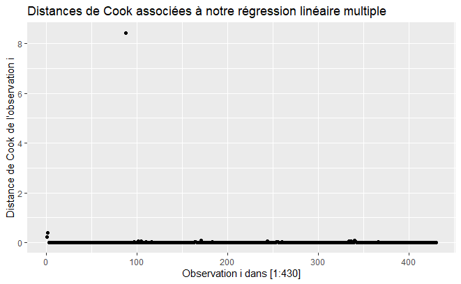

Ainsi, il y a une valeur fortement abérrante : c’est l’observation n°88. En observant de plus près, après avoir retiré cette dernière, nous nous rendons compte que les observations 1,2 et 252 posent également problème. Les effets de levier sont trop importants.

En les retirant, le graphique des distances de cook devient :

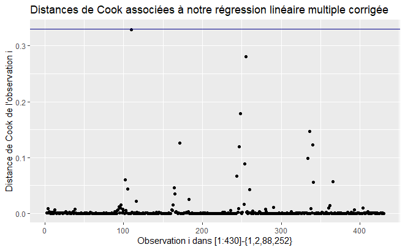

Ainsi, la plus grande distance de cook est inférieure à 0.33. Il n’y a plus d’effet de levier notoire.

Nous pouvons désormais refaire notre modélisation sans ces quatre valeurs “abérrantes”:

On a :

$\forall i \in [1;430] \backslash\ \{1,2,88,252\} ,\\ Y_i = 26.13\times1+1.764X^1_i-36.24X^2_i-0.932X^3_i+2.078X^4_i-0.3614X^5_i+0.05669X^6_i+6.825e^-4X^7_i+\hat{u}_i$

Nous pouvons ainsi étudier ce nouveau modèle en suivant exactement le même schéma que précédemment :

Comme précédemment, nous pouvons analyser cette régression linéaire multiple, en dressant notamment un tableau :

[output not shown]

Ainsi :

- L’écart-type standard des résidus diminue,
- Le R² et le R² ajusté augmentent
- Cependant, la significativité des variables change :

  Ainsi, la p-value associée au test de Student pour la variable $X^6$ passe à plus de 0.09, ce qui est supérieur à notre seuil de 5%. Ainsi, dans la prochaine sous-partie, nous allons chercher la meilleure modélisation linéaire de notre problème.

Globalement, cette modélisation est meilleure : un meilleur écart-type standard ainsi qu’un meilleur R² (comparaison pertinente vu que les deux modèles sont de même taille).

#### 3) Meilleur modèle de régression linéaire

Selon le modèle que nous choisirons, les observations abérrantes, s’il y en a, ne seront pas forcément les mêmes. C’est pourquoi nous nous proposons de retravailler dans un premier temps avec la totalité de nos données, afin d’être sûrs de ne pas passer à côté de la modélisation optimale.

En utilisant la r-procédure leaps(), nous sommes capables de sélectionner la modélisation possédant le R² ajusté le plus élevé, c’est-à-dire celle qui explique au mieux nos données.

- Tout d’abord, pour ce qui est de la totalité de nos données, le meilleur modèle est celui comprenant tous les régresseurs avec, on le rappelle, un R² ajusté de 0.55.

  Pour ce qui est du modèle ne comprenant que les variables les plus significatives (notées 3 étoiles, *** par R : $1$,$X^1$,$X^7$ et $X^7$ ), son R² est de 0.477. Ainsi, toutes les variables jugées significatives par le test de Student ajoutent une plus-value au modèle.
- Ensuite, pour ce qui est des données sans les quatre observations jugées abérrantes pour le modèle de régression linéaire multiple à 8 régresseurs (dont l’intercept), le meilleur R² ajusté est encore une fois pour le modèle avec le plus de régresseurs (avec une valeur de 0.568), mais est suivi de près par le modèle comprenant tous les régresseurs sauf $X^6$, que le test de Student avait jugé non significative (avec une valeur de 0.566).

  Pourtant, sa présence fait augmenter le R². Ainsi, nous sommes forcés de constater que celle-ci est bien significative dans notre modèle. Le problème vient de la sélection du seuil de 5% pour la p-value du test de Student (celle-ci étant à 9.32% dans les faits).

En conclusion : dans les deux cas, les meilleurs modèles pour ce qui est de l’ajustement de nos régresseurs à notre cible $Y$ sont les modèles prenant en compte tous les régresseurs. Ainsi, notre choix de facteurs explicatifs est pertinent dans sa globalité.

Dans la partie suivante, et afin de conclure notre projet, nous allons chercher à prédire la valeur marchande de joueurs en fonnction de leurs caractéristiques, toujours en nous appuyant sur une modélisation linéaire.

# UC Predict : prédiction

#### 1) predict.lm

On commence par chercher le meilleur modèle. Pour ce faire, nous utilisons à nouveau la r-procédure leaps() afin de trouver le modèle avec le Cp de Mallows le plus proche du nombre de régresseurs. En effet, le fait pour un modèle de régression d’avoir un Cp de Mallows faible indique que celui-ci est relativement précis (avec une variance faible) dans son estimation des paramètres de la régression linéaire. Cela en fait ainsi un modèle de choix en vue d’une éventuelle prévision de valeur marchande, en ayant la donnée des caractéristiques des joueurs.

Poursuivons en dressant un mini-tableau des résultats obtenus :

| Données considérées | Cp de Mallows optimal | Modèle associé |
| --- | --- | --- |
| Toutes (430 observations) | 14.19019 | Tous les régresseurs sauf $X^6$ |
| Toutes sauf les observations abérrantes précédentes | 8.83061 | Tous les régresseurs sauf $X^6$ |

Ainsi, dans les deux cas de figure, on ne considère pas $X^6$ (le nombre de sélections internationales) comme un régresseur pertinent.

Etudions maintenant de près cette modélisation, et regardons si nous pouvons déceler des effets de levier supplémentaires, puisque cela a un effet sur la variance moyenne des résidus et donc sur le Cp de Mallows.

En prenant en compte les observations non abérrantes, nous pouvons tracer le grapique des distances de Cook :

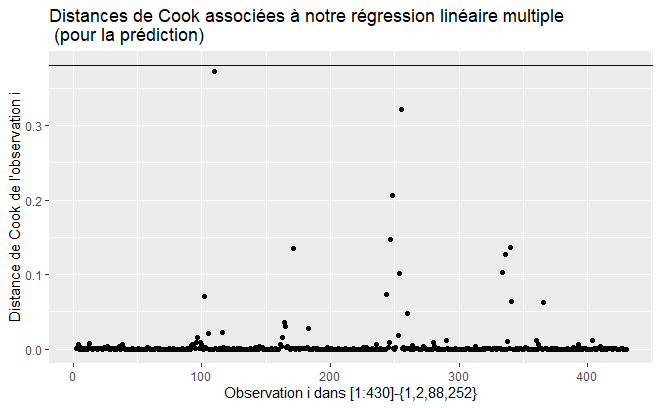

Toutes les distances de Cook sont en-dessous de 0.38. Nous décidons de garder cette modélisation pour la prédiction. On a finalement :

$\forall i \in [1;430] \backslash\ \{1,2,88,252\} ,\\ Y_i = 28.14\times1+2.181X^1_i-51.29X^2_i-0.8489X^3_i+1.771X^4_i-0.5744X^5_i+2.033e^-4X^7_i+\hat{u}_i$

Nous pouvons ainsi dresser le tableau sommaire suivant :

[output not shown]

Le R² ajusté est un peu moins bon que si l’on prenait tous les régresseurs, l’écart-type standard des résidus également, mais le Cp de Mallows est minimisé, et bien plus proche du nombre de régresseurs que tout autre modèle (le Cp de Mallows aurait été de 69.29 si l’on avait pris $X^6$ dans la modélisation).

Les données sur lesquelles nous nous étions basées précédemment étaient celles de la saison 2020.

Bien que nous soyons actuellement en cours d’année, nous pouvons essayer de prévoir la valeur marchande des joueurs (ou estimer serait un mot plus juste, étant donné que la valeur marchande d’un joueur existe et flucutue tout le long de sa carrière, sans attendre la fin de saison).

De ce fait, nous pourrons toujours vérifier la qualité de notre “prédiction”.

Nous nous proposons ainsi d’essayer de prédire les valeurs marchandes de 15 joueurs sélectionnés au hasard. Nous avons le tableau de leurs caractéristiques (valeur marchande $Y$ et nombre de sélections internationales $X^6$ compris) suivant :

| Y | X1 | X2 | X3 | X4 | X5 | X6 | X7 |
| --- | --- | --- | --- | --- | --- | --- | --- |
| 110 | 32 | 0.4848485 | 20 | 3 | 5 | 10 | 9390.1 |
| 60 | 42 | 0.4883721 | 32 | 2 | 1 | 118 | 22100.0 |
| 42 | 32 | 0.5161290 | 25 | 2 | 4 | 38 | 1744.6 |
| 120 | 34 | 0.6071429 | 27 | 3 | 7 | 53 | 13200.0 |
| 110 | 23 | 0.4181818 | 28 | 2 | 6 | 69 | 56200.0 |
| 85 | 24 | 0.4285714 | 28 | 2 | 7 | 89 | 4800.0 |
| 80 | 36 | 0.4736842 | 33 | 0 | 3 | 142 | 19800.0 |
| 25 | 28 | 0.5000000 | 33 | 1 | 2 | 81 | 50400.0 |
| 35 | 25 | 0.5000000 | 29 | 2 | 7 | 10 | 106.5 |
| 160 | 32 | 0.4155844 | 22 | 1 | 2 | 42 | 56100.0 |

[output cut: 5 more lines]

Ainsi, en utilisant la r-procédure predict.lm(), et en lui fournissant notre modèle ainsi que notre tableau (sans $Y$ et $X^6$), nous sommes capables d’obtenir une prédiction (ou estimation) de la valeur marchande de ces joueurs. Nous pouvons ainsi comparer les valeurs de $Y$ et $\hat{Y}$ $\forall i \in [1;15]$

Nous exprimerons ces résultats sous la forme d’un tableau (étant donné que l’on a que 15 observations) :

[output not shown]

Ainsi, il en ressort deux statistiques principales :

- La moyenne des résidus $\overline{\hat{u}}=17.73$ : Le modèle de prédiction a donc tendance, en moyenne, à sous-estimer la valeur marchande des joueurs sélectionnés.
- L’écart-type des résidus : $\sigma_{\hat{u}} = 33.18$, que nous considérons comme étant très élevé.

Ainsi, la r-procédure predict.lm() ne semble pas adaptée à des valeurs de ce type.

Or, nous avions, dans notre dataframe de base (de 430 observations), des valeurs marchandes très hautes, allant jusqu’à 180. Le étudier plus en détail pourrait nous permettre de mieux comprendre le lien entre une très haute valeur marchande et les caractéristiques du joueur en question. C’est pourquoi nous pensons qu’utiliser le machine learning serait efficace dans ce cas de figure.